# Individual-level variations in malaria susceptibility and acquisition of clinical protection

Data overview and statistical analysis

Mario Recker

December 2020

# Load libraries and relevant data

```r
library(tidyverse)
library(rstanarm)
library(viridis)
library(ggsci)
library(patchwork)
library(ggpmisc)
library(bayesplot)
library(arsenal)

DF = read.csv('spatioTemporalEpisodeHistories.csv')
```

## Data overview

The data contains information about individual clinical malaria episode history of 544 children aged 1-12 years enrolled in the Junju birth cohort. The data is structured as follows:

| Variable | Type | Description |
| --- | --- | --- |
| Participant.ID | categorical | a child’s unique identifier |
| Year | numerical | year of sampling |
| Age | numerical | age in years |
| BirthYear | numerical | a child’s year of birth |
| BirthQuarter | categorical | birth quarter, Q1: Jan-Mar, Q2: Apr-Jun, Q3: Jul-Sep, Q4: Oct-Dec |
| Genotype | categorical | sickle cell trait (AA: normal, AS: heterozygous sickle cell carrier) |
| PI | numerical | prevalence index, summary statistic of clinical malaria incidence in the surrounding area |
| GotEpisode | categorical | incidence of clinical episode this year (yes / no) |
| Episodes | numerical | number of episodes this year |
| PrevEpisodes | numerical | total number of episodes before this year |
| CumEpisodes | numerical | total number of episodes, including this year |

## Data summary

```r
tabl1 = tableby(Year ~ ., data = DF[,2:11])
summary(tabl1, text=F)
```

|  | 2006 (N=266) | 2007 (N=286) | 2008 (N=305) | 2009 (N=314) | 2010 (N=320) | 2011 (N=329) | 2012 (N=324) | 2013 (N=321) | 2014 (N=302) | 2015 (N=280) | 2016 (N=266) | 2017 (N=230) | 2018 (N=224) | Total (N=3767) | p value |
| --- | --- | --- | --- | --- | --- | --- | --- | --- | --- | --- | --- | --- | --- | --- | --- |
| **Age** |  |  |  |  |  |  |  |  |  |  |  |  |  |  | < 0.001 |
| Mean (SD) | 4.135 (2.005) | 4.846 (2.203) | 5.482 (2.494) | 5.901 (2.819) | 6.350 (3.180) | 6.821 (3.435) | 6.460 (3.565) | 6.383 (3.625) | 6.530 (3.499) | 6.525 (3.440) | 6.346 (3.334) | 6.339 (3.166) | 6.589 (3.114) | 6.066 (3.205) |  |
| Range | 1.000 - 10.000 | 1.000 - 11.000 | 1.000 - 12.000 | 1.000 - 11.000 | 1.000 - 12.000 | 1.000 - 12.000 | 1.000 - 12.000 | 1.000 - 12.000 | 1.000 - 12.000 | 1.000 - 12.000 | 1.000 - 12.000 | 1.000 - 12.000 | 1.000 - 12.000 | 1.000 - 12.000 |  |
| **BirthYear** |  |  |  |  |  |  |  |  |  |  |  |  |  |  | < 0.001 |
| Mean (SD) | 2001.865 (2.005) | 2002.154 (2.203) | 2002.518 (2.494) | 2003.099 (2.819) | 2003.650 (3.180) | 2004.179 (3.435) | 2005.540 (3.565) | 2006.617 (3.625) | 2007.470 (3.499) | 2008.475 (3.440) | 2009.654 (3.334) | 2010.661 (3.166) | 2011.411 (3.114) | 2005.713 (4.371) |  |
| Range | 1996.000 - 2005.000 | 1996.000 - 2006.000 | 1996.000 - 2007.000 | 1998.000 - 2008.000 | 1998.000 - 2009.000 | 1999.000 - 2010.000 | 2000.000 - 2011.000 | 2001.000 - 2012.000 | 2002.000 - 2013.000 | 2003.000 - 2014.000 | 2004.000 - 2015.000 | 2005.000 - 2016.000 | 2006.000 - 2017.000 | 1996.000 - 2017.000 |  |
| **BirthQuarter** |  |  |  |  |  |  |  |  |  |  |  |  |  |  | 0.964 |
| Q1 | 63 (23.7%) | 65 (22.7%) | 79 (25.9%) | 84 (26.8%) | 86 (26.9%) | 88 (26.7%) | 80 (24.7%) | 85 (26.5%) | 77 (25.5%) | 77 (27.5%) | 64 (24.1%) | 62 (27.0%) | 62 (27.7%) | 972 (25.8%) |  |
| Q2 | 66 (24.8%) | 71 (24.8%) | 72 (23.6%) | 74 (23.6%) | 73 (22.8%) | 75 (22.8%) | 82 (25.3%) | 86 (26.8%) | 78 (25.8%) | 76 (27.1%) | 69 (25.9%) | 53 (23.0%) | 51 (22.8%) | 926 (24.6%) |  |
| Q3 | 78 (29.3%) | 83 (29.0%) | 85 (27.9%) | 86 (27.4%) | 90 (28.1%) | 96 (29.2%) | 99 (30.6%) | 98 (30.5%) | 93 (30.8%) | 86 (30.7%) | 85 (32.0%) | 73 (31.7%) | 68 (30.4%) | 1120 (29.7%) |  |
| Q4 | 59 (22.2%) | 67 (23.4%) | 69 (22.6%) | 70 (22.3%) | 71 (22.2%) | 70 (21.3%) | 63 (19.4%) | 52 (16.2%) | 54 (17.9%) | 41 (14.6%) | 48 (18.0%) | 42 (18.3%) | 43 (19.2%) | 749 (19.9%) |  |
| **Genotype** |  |  |  |  |  |  |  |  |  |  |  |  |  |  | 0.653 |
| AA | 218 (82.0%) | 232 (81.1%) | 250 (82.0%) | 260 (82.8%) | 260 (81.2%) | 271 (82.4%) | 277 (85.5%) | 274 (85.4%) | 261 (86.4%) | 242 (86.4%) | 226 (85.0%) | 191 (83.0%) | 187 (83.5%) | 3149 (83.6%) |  |
| AS | 48 (18.0%) | 54 (18.9%) | 55 (18.0%) | 54 (17.2%) | 60 (18.8%) | 58 (17.6%) | 47 (14.5%) | 47 (14.6%) | 41 (13.6%) | 38 (13.6%) | 40 (15.0%) | 39 (17.0%) | 37 (16.5%) | 618 (16.4%) |  |
| **PI** |  |  |  |  |  |  |  |  |  |  |  |  |  |  | < 0.001 |
| Mean (SD) | 0.228 (0.059) | 0.234 (0.061) | 0.484 (0.089) | 0.392 (0.098) | 0.441 (0.079) | 0.466 (0.090) | 0.162 (0.034) | 0.492 (0.080) | 0.563 (0.092) | 0.499 (0.131) | 0.354 (0.156) | 0.394 (0.133) | 0.728 (0.101) | 0.414 (0.171) |  |
| Range | 0.109 - 0.316 | 0.070 - 0.354 | 0.327 - 0.668 | 0.173 - 0.554 | 0.272 - 0.593 | 0.217 - 0.653 | 0.090 - 0.241 | 0.253 - 0.641 | 0.377 - 0.720 | 0.197 - 0.665 | 0.029 - 0.610 | 0.034 - 0.705 | 0.126 - 0.874 | 0.029 - 0.874 |  |
| **GotEpisode** |  |  |  |  |  |  |  |  |  |  |  |  |  |  | < 0.001 |
| no | 195 (73.3%) | 203 (71.0%) | 149 (48.9%) | 180 (57.3%) | 171 (53.4%) | 164 (49.8%) | 259 (79.9%) | 138 (43.0%) | 92 (30.5%) | 114 (40.7%) | 154 (57.9%) | 126 (54.8%) | 53 (23.7%) | 1998 (53.0%) |  |
| yes | 71 (26.7%) | 83 (29.0%) | 156 (51.1%) | 134 (42.7%) | 149 (46.6%) | 165 (50.2%) | 65 (20.1%) | 183 (57.0%) | 210 (69.5%) | 166 (59.3%) | 112 (42.1%) | 104 (45.2%) | 171 (76.3%) | 1769 (47.0%) |  |
| **Episodes** |  |  |  |  |  |  |  |  |  |  |  |  |  |  | < 0.001 |
| Mean (SD) | 0.316 (0.568) | 0.367 (0.661) | 0.882 (1.129) | 0.739 (1.034) | 0.834 (1.128) | 0.915 (1.189) | 0.238 (0.530) | 1.187 (1.393) | 1.768 (1.715) | 1.100 (1.223) | 0.650 (0.968) | 0.657 (0.881) | 1.973 (1.797) | 0.882 (1.245) |  |
| Range | 0.000 - 3.000 | 0.000 - 4.000 | 0.000 - 7.000 | 0.000 - 5.000 | 0.000 - 5.000 | 0.000 - 6.000 | 0.000 - 4.000 | 0.000 - 7.000 | 0.000 - 9.000 | 0.000 - 6.000 | 0.000 - 6.000 | 0.000 - 4.000 | 0.000 - 9.000 | 0.000 - 9.000 |  |
| **PrevEpisodes** |  |  |  |  |  |  |  |  |  |  |  |  |  |  | < 0.001 |
| Mean (SD) | 0.263 (0.548) | 0.538 (0.797) | 0.852 (1.130) | 1.634 (1.785) | 2.169 (2.372) | 2.842 (2.994) | 3.574 (3.664) | 3.508 (3.847) | 4.566 (4.655) | 5.861 (5.395) | 5.959 (5.774) | 5.896 (5.780) | 5.634 (5.427) | 3.221 (4.247) |  |
| Range | 0.000 - 4.000 | 0.000 - 4.000 | 0.000 - 6.000 | 0.000 - 10.000 | 0.000 - 12.000 | 0.000 - 15.000 | 0.000 - 20.000 | 0.000 - 20.000 | 0.000 - 25.000 | 0.000 - 29.000 | 0.000 - 33.000 | 0.000 - 31.000 | 0.000 - 27.000 | 0.000 - 33.000 |  |
| **CumEpisodes** |  |  |  |  |  |  |  |  |  |  |  |  |  |  | < 0.001 |
| Mean (SD) | 0.579 (0.812) | 0.906 (1.143) | 1.734 (1.775) | 2.373 (2.372) | 3.003 (2.981) | 3.757 (3.588) | 3.812 (3.816) | 4.695 (4.543) | 6.334 (5.418) | 6.961 (5.870) | 6.609 (6.073) | 6.552 (6.125) | 7.607 (6.341) | 4.103 (4.791) |  |
| Range | 0.000 - 4.000 | 0.000 - 6.000 | 0.000 - 10.000 | 0.000 - 12.000 | 0.000 - 15.000 | 0.000 - 20.000 | 0.000 - 20.000 | 0.000 - 25.000 | 0.000 - 31.000 | 0.000 - 33.000 | 0.000 - 35.000 | 0.000 - 34.000 | 0.000 - 30.000 | 0.000 - 35.000 |  |

# Overview of Junju epidemiology

## Incidence over time

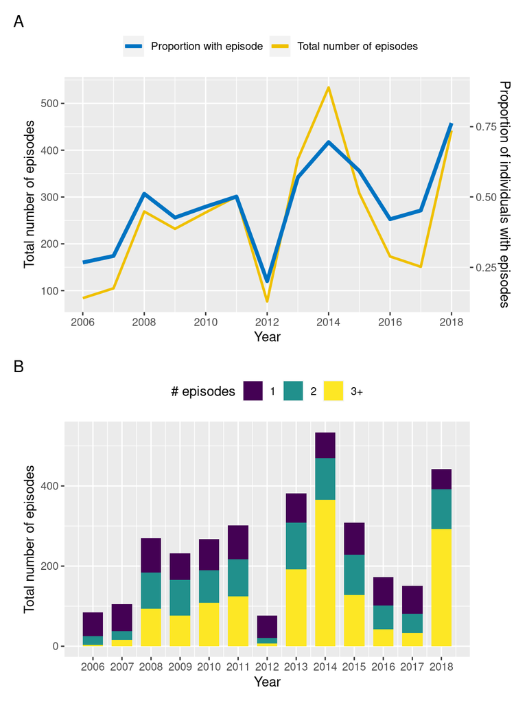

```r
fig1a = DF %>%
  group_by(Year) %>%
  summarise(NEpisodes = sum(Episodes),
            NIndividuals = length(unique(Participant.ID)),
            NGotInfected = length(which(GotEpisode=='yes'))) %>%
  ggplot(aes(x = Year, y = NEpisodes)) +
  geom_line(size=1,aes(color='Total number of episodes')) +
  geom_line(aes(y=600*NGotInfected/NIndividuals,color='Proportion with episode'),size=1.5) +
  scale_y_continuous(sec.axis=sec_axis(~ . / 600, name='Proportion of individuals with episodes')) +
  scale_x_continuous(breaks = seq(min(DF$Year), max(DF$Year), by = 2)) +
  labs(y='Total number of episodes',
       color = '',
       tag = 'A') +
  theme(legend.position = 'top') +
  scale_color_jco()

fig1b = DF %>%
  filter(GotEpisode == 'yes') %>%
  unique() %>%
  group_by(Year) %>%
  mutate(EpiCat = ifelse(Episodes==1,'1',ifelse(Episodes>2,'3+','2'))) %>%
  ggplot(aes(x=Year, y=Episodes, fill=EpiCat)) +
  geom_bar(position="stack", stat="identity", width = 0.7) +
  scale_fill_viridis_d(direction=1) +
  scale_x_continuous(breaks = seq(min(DF$Year), max(DF$Year), by = 1)) +
  theme(legend.position = 'top') +
  labs(y = 'Total number of episodes',
       fill = '# episodes',
       tag = 'B')

fig1a / fig1b
```

## Individual infection histories, stratified by birth year

Use all children for a select number of birth years and highlight those with the sickle cell trait (heterozygote, AS)

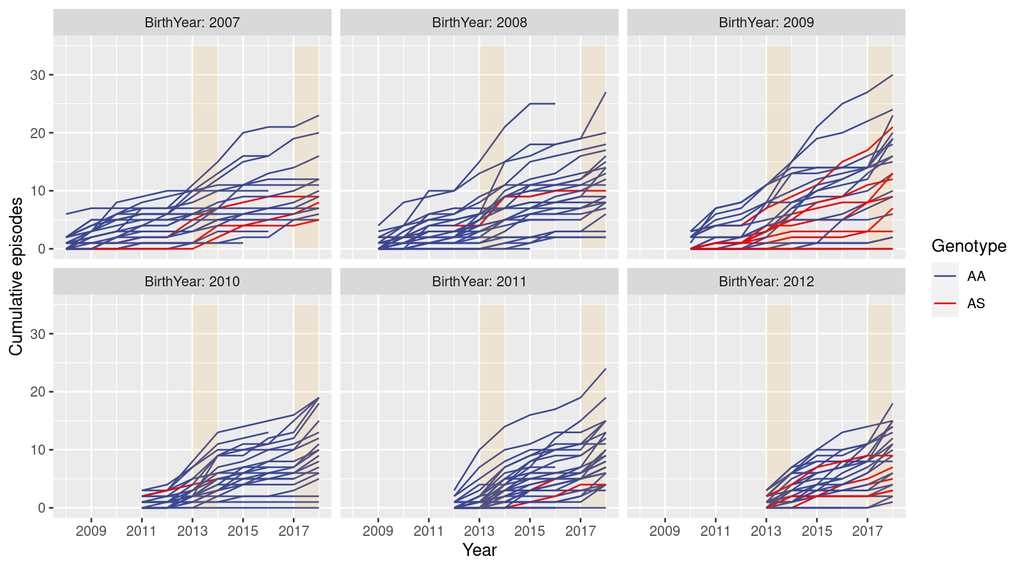

```r
rects = data.frame(start=c(2013,2017), end=c(2014,2018), group=c(1,2))

DF %>%
  filter(BirthYear %in% 2007:2012) %>%
  mutate(label = paste0('Birth year = ',BirthYear)) %>%
  ggplot(aes(x = Year, y = CumEpisodes, group = Participant.ID, col = Genotype)) +
  geom_line() +
  facet_wrap(~BirthYear, labeller = label_both) +
  scale_x_continuous(breaks=seq(2007,2018,by=2)) +
  scale_color_aaas() +
  geom_rect(data=rects, inherit.aes=FALSE, aes(xmin=start, xmax=end, ymin=0, ymax=max(DF$CumEpisodes),
                                               group=group), color="transparent", fill="orange", alpha=0.1) +
  labs(y='Cumulative episodes')
```

## Effect of age and previous episodes on risk of clinical malaria

Note, AS children are filtered for the second graph (not the first one, though) because of its known protective effect, which affects theboth the previous number of episodes and probability of an episode in a given year.

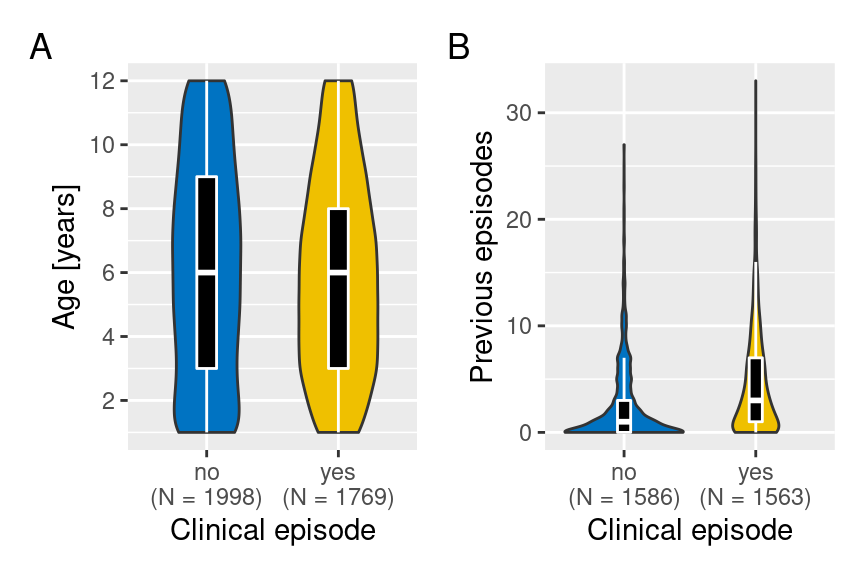

```r
fa = DF %>%
  group_by(GotEpisode) %>%
  mutate(n = n()) %>%
  mutate(label = paste0(GotEpisode,'\n(N = ',n,')')) %>%
  ggplot(aes(x = label, y = Age, fill=GotEpisode)) +
  geom_violin(width = 0.6) +
  geom_boxplot(width = 0.15, outlier.shape = NA, col='white', fill='black') +
  scale_y_continuous(breaks=seq(2,15,by=2)) +
  theme(legend.position = '') +
  labs(x = 'Clinical episode',
       y = 'Age [years]',
       tag = 'A') +
  scale_fill_jco()

fb = DF %>%
  filter(Genotype=='AA') %>%
  group_by(GotEpisode) %>%
  mutate(n = n()) %>%
  mutate(label = paste0(GotEpisode,'\n(N = ',n,')')) %>%
  ggplot(aes(x = label, y = PrevEpisodes, fill=GotEpisode)) +
  geom_violin(width = 0.9) +
  geom_boxplot(width = 0.1, outlier.shape = NA, col='white', fill='black') +
  theme(legend.position = '') +
  labs(x = 'Clinical episode',
       y = 'Previous epsisodes',
       tag = 'B') +
  scale_fill_jco()


fa + fb
```

### Effect of previous episodes, stratified by age

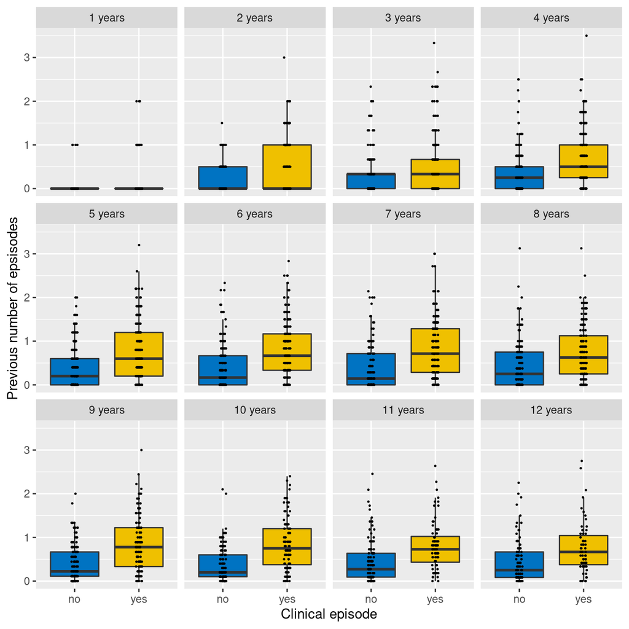

```r
DF %>%
  filter(Genotype=='AA') %>%
  mutate(label = paste(Age,'years',sep=' ')) %>%
  mutate(label = factor(label, levels = paste(1:12,'years',sep=' '))) %>%
  ggplot(aes(x = GotEpisode, y = PrevEpisodes/Age, fill=GotEpisode)) +
  geom_boxplot(outlier.shape = NA) +
  geom_jitter(height=0,width=0.05, size=0.25) +
  facet_wrap(~label) +
  theme(legend.position = '') +
  labs(x = 'Clinical episode',
       y = 'Previous number of epsisodes') +
  scale_fill_jco()
```

## Effect of birth quarter on total number of clinical episodes

For this analysis we only take a single reading from each child at a given age (here: 6 years) as the number of episdoes should be directlty linked to age. Because AS is not assumed to make a difference, these are kept in.

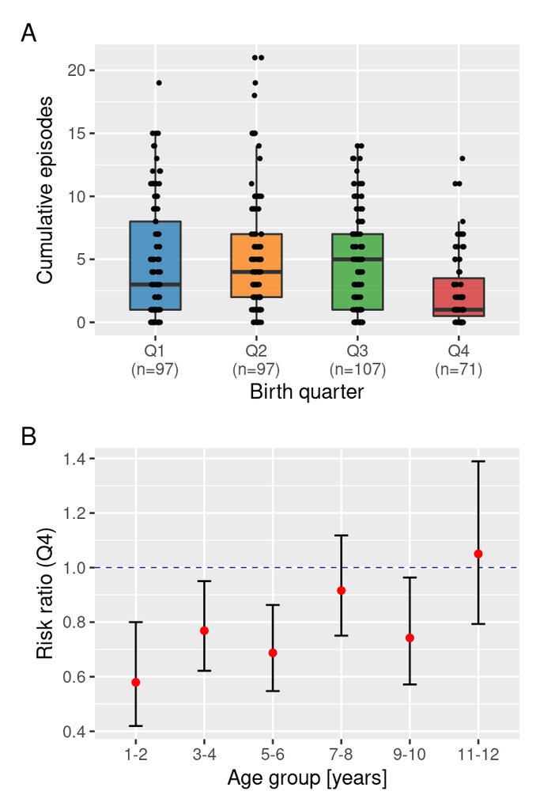

```r
##### calculate risk ratio ####
datalist = list()
for(i in 1:6){
  age = i*2
  IDs = which(DF$Age>(i-1)*2 & DF$Age<=i*2)
  Na = length(which(DF$BirthQuarter[IDs]=='Q4'))
  a = length(which(DF$BirthQuarter[IDs]=='Q4' & DF$GotEpisode[IDs]=='yes'))
  Nb = length(IDs)-Na
  b = length(which(DF$BirthQuarter[IDs]!='Q4' & DF$GotEpisode[IDs]=='yes'))
  dat = matrix(c(Nb-b,b,Na-a,a),2,2,byrow=TRUE)
  risk = epitools::riskratio(dat,conf.level=0.95)
  datalist[[age]] = data.frame(Age = paste0(1+2*(i-1),'-',2*i),
                               N = paste0(1+2*(i-1),'-',2*i,'\n(N=',length(IDs),')'),
                               RR = risk$measure[2,1],
                               RR_CI_low = risk$measure[2,2],
                               RR_CI_high = risk$measure[2,3])
}

fa = DF %>%
  filter(Age == 6) %>%
  group_by(BirthQuarter) %>%
  mutate(n = n()) %>%
  mutate(label = paste0(BirthQuarter,'\n(n=',n,')')) %>%
  ggplot(aes(x = label, y = CumEpisodes, group = BirthQuarter, fill = factor(BirthQuarter))) +
  geom_boxplot(width=0.5,alpha=0.75, outlier.shape = NA) +
  geom_jitter(width = 0.05, height = 0, size=0.7) +
  scale_fill_d3() +
  labs(x = 'Birth quarter',
       y = 'Cumulative episodes',
       tag = 'A') +
  theme(legend.position = '')



fb = do.call(rbind,datalist) %>%
  ggplot(aes(x = Age, y = RR)) +
  geom_hline(yintercept = 1, linetype=2, size=0.25, col='darkblue') +
  geom_errorbar(aes(ymin=RR_CI_low,ymax=RR_CI_high), width=0.2) +
  geom_point(col='red') +
  labs(y = 'Risk ratio (Q4)',
       x = 'Age group [years]',
       tag = 'B')

fa / fb
```

## Statistical modelling

All analyses are done in a Bayesian framework, using *rstanarm* or *brms* (both are different front ends that run stan under hood; rstanarm is definitely faster but brms does come with other functionality for plotting the results, like conditional effect plost).

### Create data frame for downstream analysis

To facilitate comparison between effects of different covariates (and help with convergence) we centre and scale all numerical variables. Note, we revert back to the original data frame for the conditional effect plots to display *re-scaled* parameter ranges.

```r
XY = DF %>%
  mutate(EpiRate = PrevEpisodes/(1+Age),
         BirthYear = as.factor(BirthYear),
         Year = as.factor(Year)) %>%
  mutate(PI = scale(PI, center = T, scale = T),
         EpiRate = scale(EpiRate, center = T, scale = T),
         PrevEpisodes = scale(PrevEpisodes, center = T, scale = T),
         Age = scale(Age, center = T, scale = T))

YY = XY %>%
  filter(Genotype=='AA')
```

### Model (I)

For this model we consider the following covariates: *PI*, *Age*, *Genotype* and *BirthQuarter*. That is, we include sickle cell carriers in order to have a direct comparison (of effect sizes) between this and other *protective effects*.

1. run model

```r
fullMod = stan_glmer(GotEpisode ~ PI + Genotype  + BirthQuarter + Age + (1|Participant.ID),
                     family = binomial, data = XY, chains = 4, cores = 4)
```

2. plot

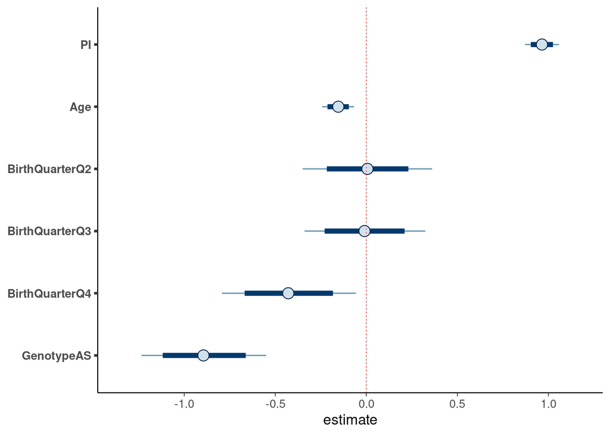

```r
bayesplot_theme_set(theme_default(base_size = 12, base_family = "sans"))

plot(fullMod, "intervals", pars=c('PI','Age'), regex_pars=c("Birth","Genotype"), prob=0.8, prob_outer=0.95) +
  geom_vline(xintercept = 0, linetype='dotted', col='red', size=0.3) +
  labs(x = 'estimate')
```

#### check ‘random’ effect, i.e. distribution of intercepts

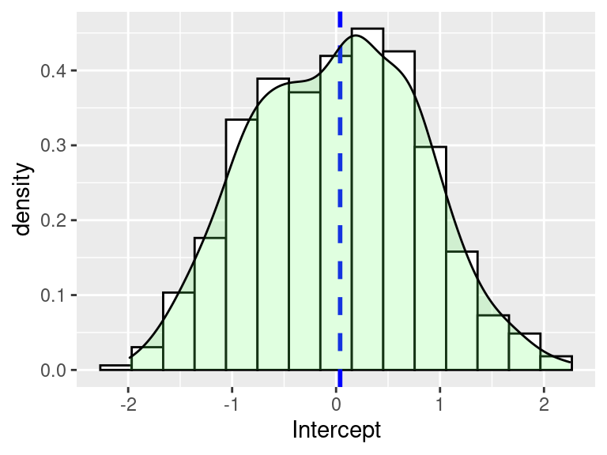

```r
u0 = ranef(fullMod)$Participant.ID
raneffect = data.frame(Participant.ID = row.names(u0),
                       Intercept = u0[,1])

ggplot(raneffect, aes(x=Intercept)) +
  geom_histogram(aes(y=..density..), color="black", fill="white", bins=15) +
  geom_vline(aes(xintercept=median(Intercept)),
             color="blue", linetype="dashed", size=1) +
  geom_density(alpha=.2, fill="#66FF66")
```

#### model comparison with non-hierarchical model using ELDP

1. run model

```r
nullMod = stan_glm(GotEpisode ~ PI + Genotype  + BirthQuarter + Age,
                   family = binomial, data = XY, chains = 4, cores = 4)
```

2. compare using loo’s ELPD

```r
loo_null = loo(nullMod)
loo_full = loo(fullMod)
print(list(loo_null, loo_full, loo_compare(loo_null,loo_full)))
```

```
[[1]]

Computed from 4000 by 3767 log-likelihood matrix

         Estimate   SE
elpd_loo  -2325.7 22.6
p_loo         7.0  0.1
looic      4651.3 45.2
------
Monte Carlo SE of elpd_loo is 0.0.

All Pareto k estimates are good (k < 0.5).
See help('pareto-k-diagnostic') for details.

[[2]]

Computed from 4000 by 3767 log-likelihood matrix

         Estimate   SE
elpd_loo  -2136.4 28.0
p_loo       289.6  5.0
looic      4272.9 56.0
------
Monte Carlo SE of elpd_loo is 0.2.

Pareto k diagnostic values:
                         Count Pct.    Min. n_eff
(-Inf, 0.5]   (good)     3758  99.8%   2351
 (0.5, 0.7]   (ok)          9   0.2%   3504
   (0.7, 1]   (bad)         0   0.0%   <NA>
   (1, Inf)   (very bad)    0   0.0%   <NA>

All Pareto k estimates are ok (k < 0.7).
See help('pareto-k-diagnostic') for details.

[[3]]
        elpd_diff se_diff
fullMod    0.0       0.0
nullMod -189.2      18.9
```

#### Conditional effect plots

1. run model

```r
brmMod = brms::brm(GotEpisode ~ PI + BirthQuarter + Age + Genotype + (1|Participant.ID),
                   family = 'categorical', data = DF, cores=4)
```

2. plot

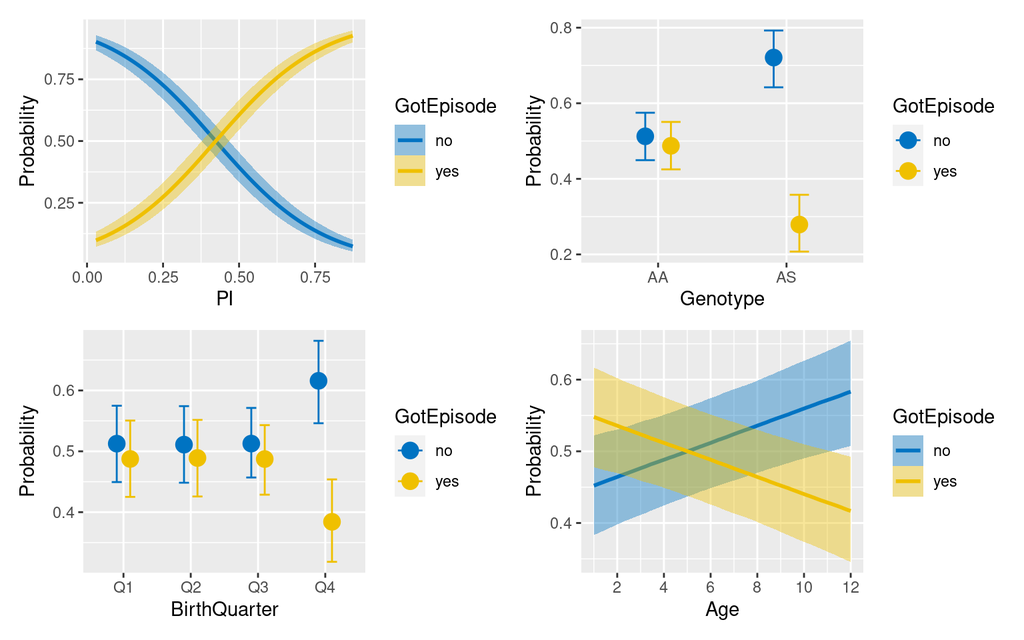

```r
plots = brms::conditional_effects(brmMod, categorical=T)

fa = plot(plots, plot=F)[[1]] +
  scale_color_jco() +
  scale_fill_jco()

fb = plot(plots, plot=F)[[4]] +
  scale_color_jco() +
  scale_fill_jco()

fc = plot(plots, plot=F)[[2]] +
  scale_color_jco() +
  scale_fill_jco()

fd = plot(plots, plot=F)[[3]] +
  scale_color_jco() +
  scale_fill_jco() +
  scale_x_continuous(breaks=seq(0,12,by=2))


(fa + fb) / (fc + fd)
```

### Model (II)

Instead of using birth quarter or genotype, here we investigate the effect of *previous episodes* on the probability of a clinical episode. As before we use both *rstanarm* and *brms* to create posterior and conditional effect plots (*brms* can also be used to produce posterior plots but creates weird variable names).

1. run model

```r
altMod = stan_glmer(GotEpisode ~ PI + PrevEpisodes*Age + (1|Participant.ID),
                     family = binomial, data = YY, chains = 4, cores = 4)
```

2. plot

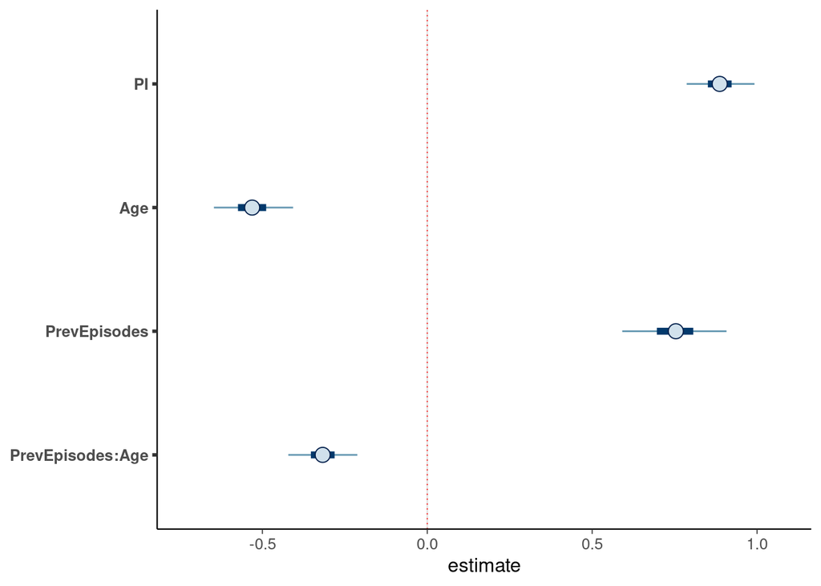

```r
plot(altMod, "intervals", pars=c('PI','Age'), regex_pars=c('Prev'), parprob=0.8,
             prob_outer=0.95) +
  geom_vline(xintercept = 0, linetype='dotted', col='red', size=0.3) +
  labs(x = 'estimate')
```

#### conditional effect plots

1. run model

```r
altbrmMod = brms::brm(GotEpisode ~ PI + PrevEpisodes*Age  + (1|Participant.ID),
                      family = 'categorical', data = DF[DF$Genotype=='AA',], cores=4)
```

2. plot

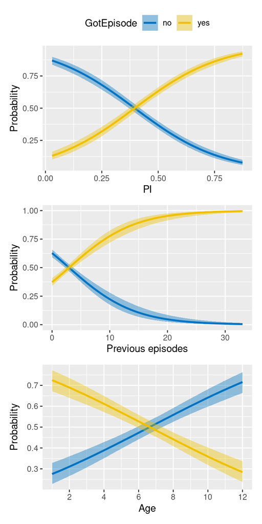

```r
plots = brms::conditional_effects(altbrmMod, categorical=T)

fa = plot(plots, plot=F)[[1]] +
  scale_color_jco() +
  scale_fill_jco() +
  theme(legend.position = 'top')

fb = plot(plots, plot=F)[[2]] +
  scale_color_jco() +
  scale_fill_jco() +
  theme(legend.position = '') +
  labs(x = 'Previous episodes')

fc = plot(plots, plot=F)[[3]] +
  scale_color_jco() +
  scale_fill_jco() +
  theme(legend.position = '') +
  scale_x_continuous(breaks=seq(0,12,by=2))


fa / fb / fc
```